# COMPSCIX 415.2 Homework 2

## 5

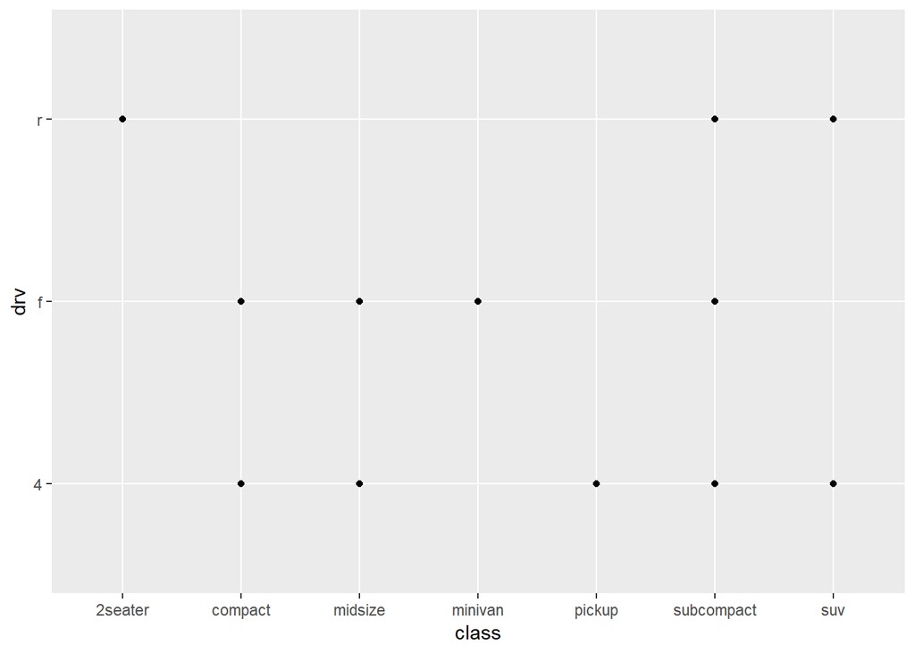

```r
ggplot(data = mpg) +
  geom_point(mapping = aes(x = class, y = drv))
```

Points on the plot are overlapping with each other

## Exercise 3.3.1

## 1

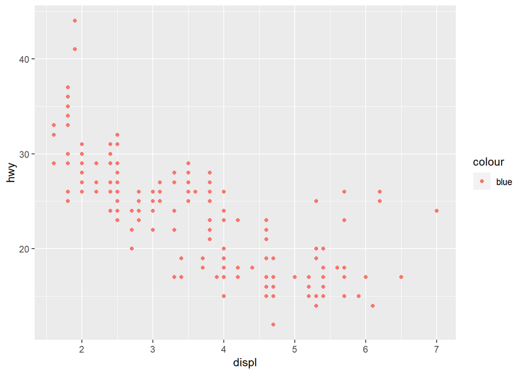

```r
ggplot(data = mpg) +
  geom_point(mapping = aes(x = displ, y = hwy, color = "blue"))
```

Blue dots are showing Red as color argument was set within aes(), not geom_point() Correct code would be like below:

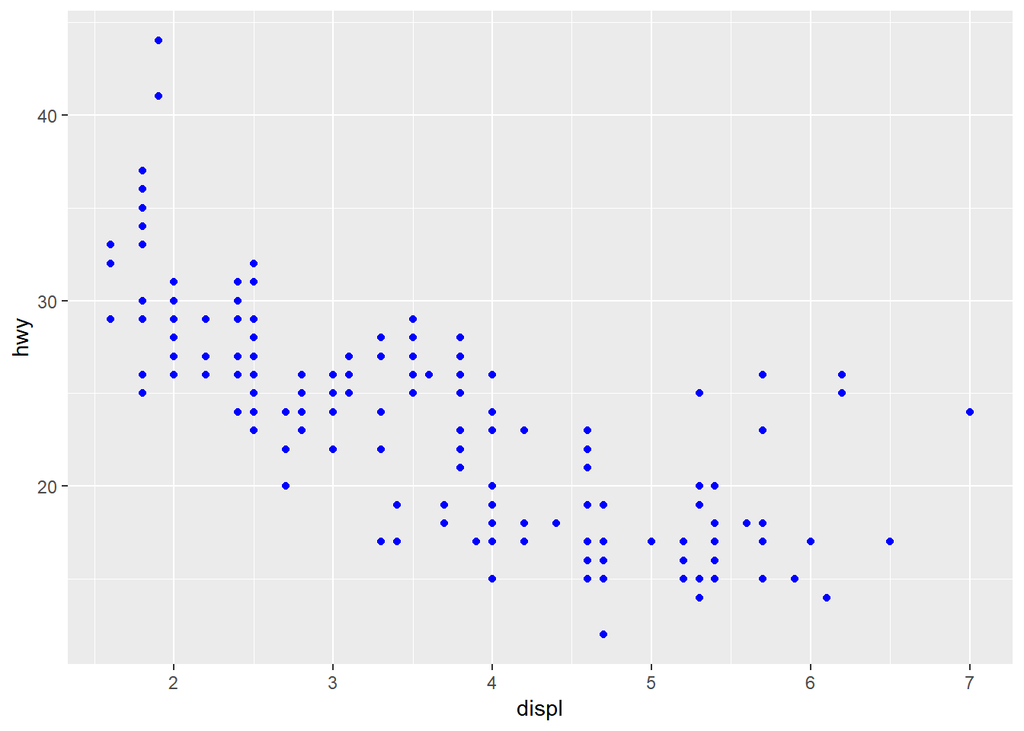

```r
ggplot(data = mpg) +
  geom_point(mapping = aes(x = displ, y = hwy), color = "blue")
```

## 2

```r
mpg
```

```
## # A tibble: 234 x 11
##    manufacturer model displ  year   cyl trans drv     cty   hwy fl    class
##    <chr>        <chr> <dbl> <int> <int> <chr> <chr> <int> <int> <chr> <chr>
##  1 audi         a4      1.8  1999     4 auto~ f        18    29 p     comp~
##  2 audi         a4      1.8  1999     4 manu~ f        21    29 p     comp~
##  3 audi         a4      2    2008     4 manu~ f        20    31 p     comp~
##  4 audi         a4      2    2008     4 auto~ f        21    30 p     comp~
##  5 audi         a4      2.8  1999     6 auto~ f        16    26 p     comp~
##  6 audi         a4      2.8  1999     6 manu~ f        18    26 p     comp~
##  7 audi         a4      3.1  2008     6 auto~ f        18    27 p     comp~
##  8 audi         a4 q~   1.8  1999     4 manu~ 4        18    26 p     comp~
##  9 audi         a4 q~   1.8  1999     4 auto~ 4        16    25 p     comp~
## 10 audi         a4 q~   2    2008     4 manu~ 4        20    28 p     comp~
## # ... with 224 more rows
```

## 3 - Map a continuous variable to color, size, and shape

## using color

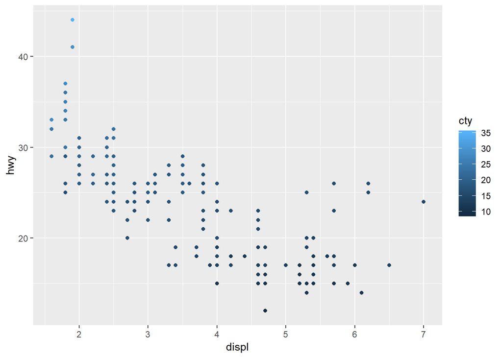

```r
ggplot(data = mpg) +
  geom_point(mapping = aes(x = displ, y = hwy, color = cty))
```

## using size

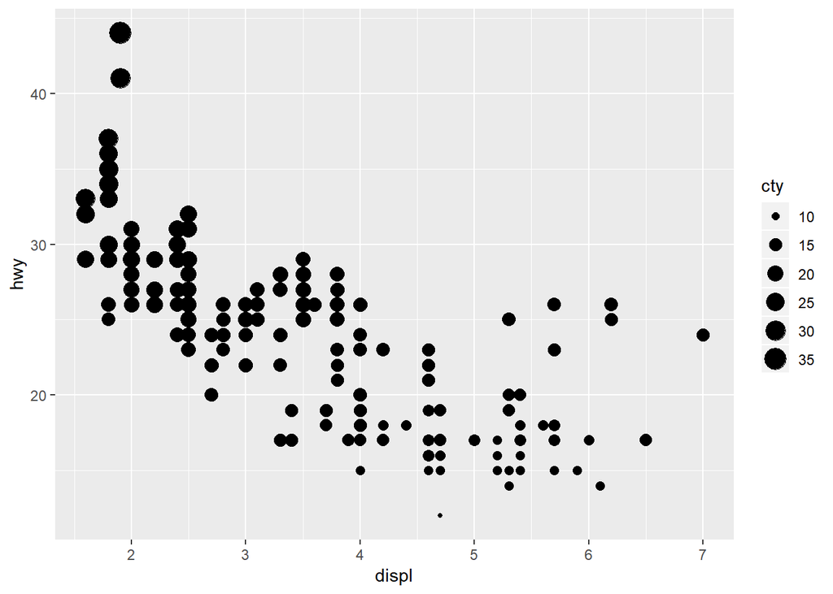

```r
ggplot(data = mpg) +
  geom_point(mapping = aes(x = displ, y = hwy, size = cty))
```

Error: A continuous variable can not be mapped to shape

continuous variables are visualized on a spectrum categorical variables are binned into discrete categories

## 4 - What happens if you map the same variable to multiple aesthetics?

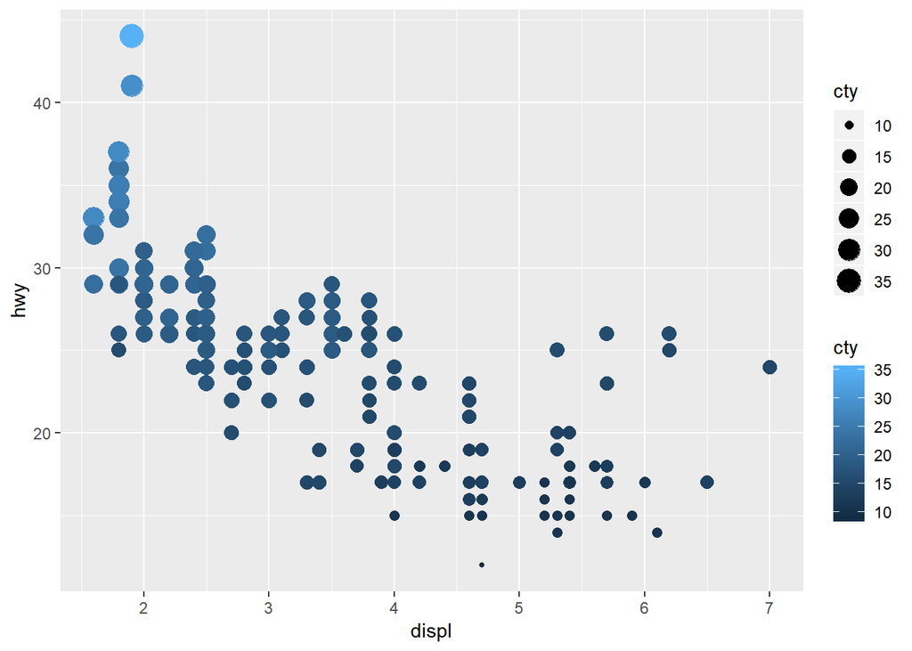

```r
ggplot(data = mpg) +
  geom_point(mapping = aes(x = displ, y = hwy, color = cty, size = cty))
```

Both aesthetics are implemented, but multiple legends are generated.

## 5 - What does the stroke aesthetic do? What shapes does it work with?

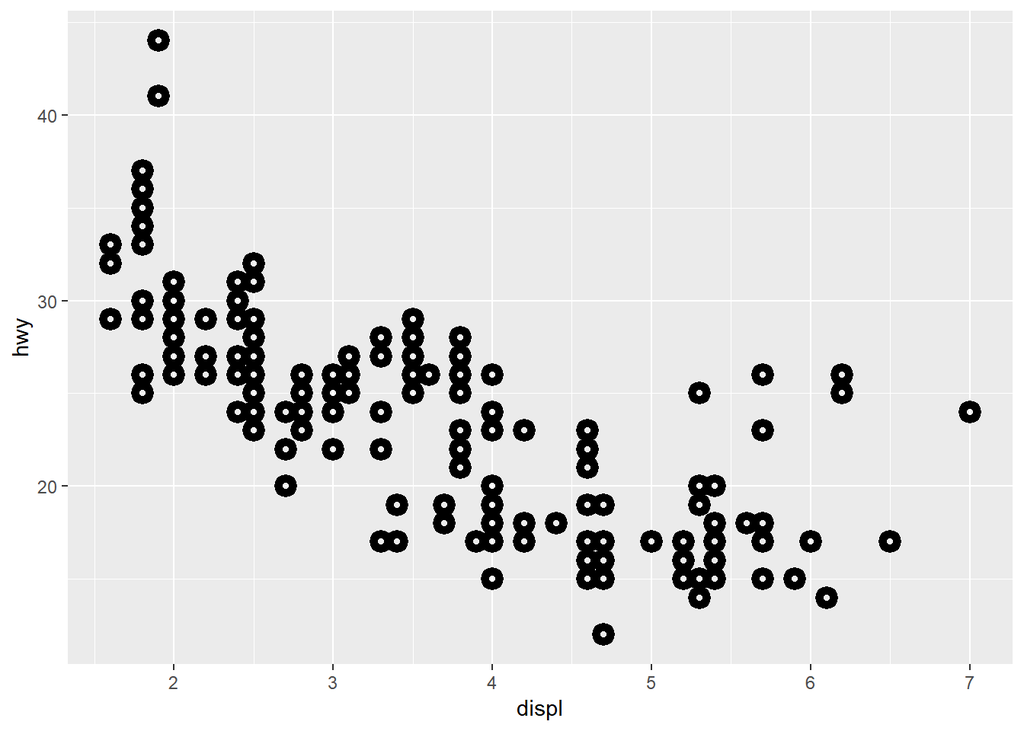

```r
ggplot(data = mpg) +
  geom_point(mapping = aes(x = displ, y = hwy), stroke = 3, shape = 21)
```

stroke adjusts the thickness of the border for shapes that can take on different colors both inside and outside.

## 6 - What happens if you map an aesthetic to something other than a variable name, like aes(colour = displ < 5)?

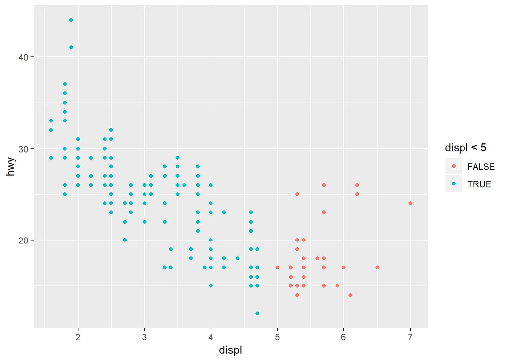

```r
ggplot(data = mpg) +
  geom_point(mapping = aes(x = displ, y = hwy, color = displ < 5))
```

displ is temporary variable to hold the result whether True or False

## Exercise 3.5.1

## 4

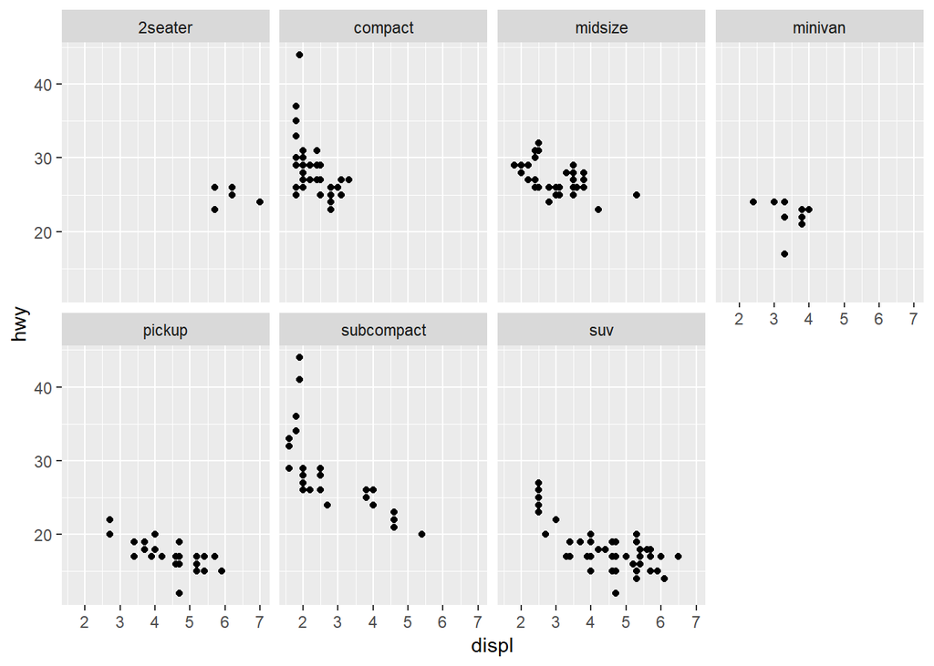

```r
ggplot(data = mpg) +
  geom_point(mapping = aes(x = displ, y = hwy)) +
  facet_wrap(~ class, nrow = 2)
```

Advantage - Faceting splits the data into separate grids and better visualizes trends within each individual facet. Disadvantage - harder to visualize the overall relationship across facets The color aesthetic is fine when your dataset is small, but with larger datasets points may begin to overlap with one another. In this situation with a colored plot, jittering may not be sufficient because of the additional color aesthetic.

## 5

```r
?facet_wrap
```

```
## starting httpd help server ... done
```

nrow, ncol - Number of rows and columns.

as.table - If TRUE, the default, the facets are laid out like a table with highest values at the bottom-right. If FALSE, the facets are laid out like a plot with the highest value at the top-right.

in `facet_grid` nrow and ncol are implied by the faceting variables. `dir` also controls the placement of the individual panels, and so isn’t an argument of `facet_grid`.

## Exercise 3.6.1

## 1 - What geom would you use to draw a line chart? A boxplot? A histogram? An area chart?

Line chart - geom_line() Boxplot - geom_boxplot() Histogram - geom_histogram() Area chart - geom_area()

## 2

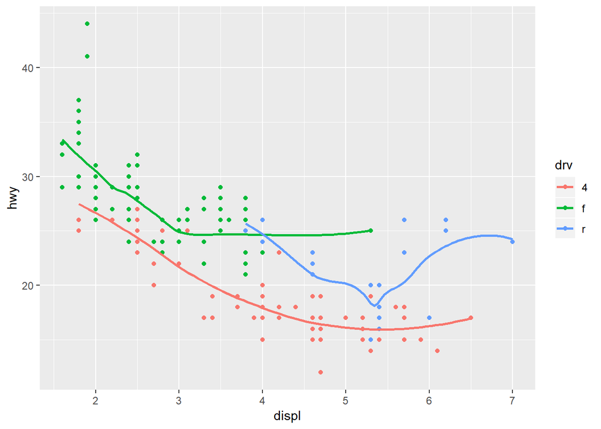

```r
ggplot(data = mpg, mapping = aes(x = displ, y = hwy, color = drv)) +
  geom_point() +
  geom_smooth(se = FALSE)
```

## 3 - What does show.legend = FALSE do? What happens if you remove it? Why do you think I used it earlier in the chapter?

It removes the legend. The aesthetics are still mapped and plotted, but the key is removed from the graph. I don’t know why used it earlier because he actually did not.

## 4 - What does the se argument to geom_smooth() do?

It determines whether or not to draw a confidence interval around the smoothing line.

## 5 - Will these two graphs look different? Why/why not?

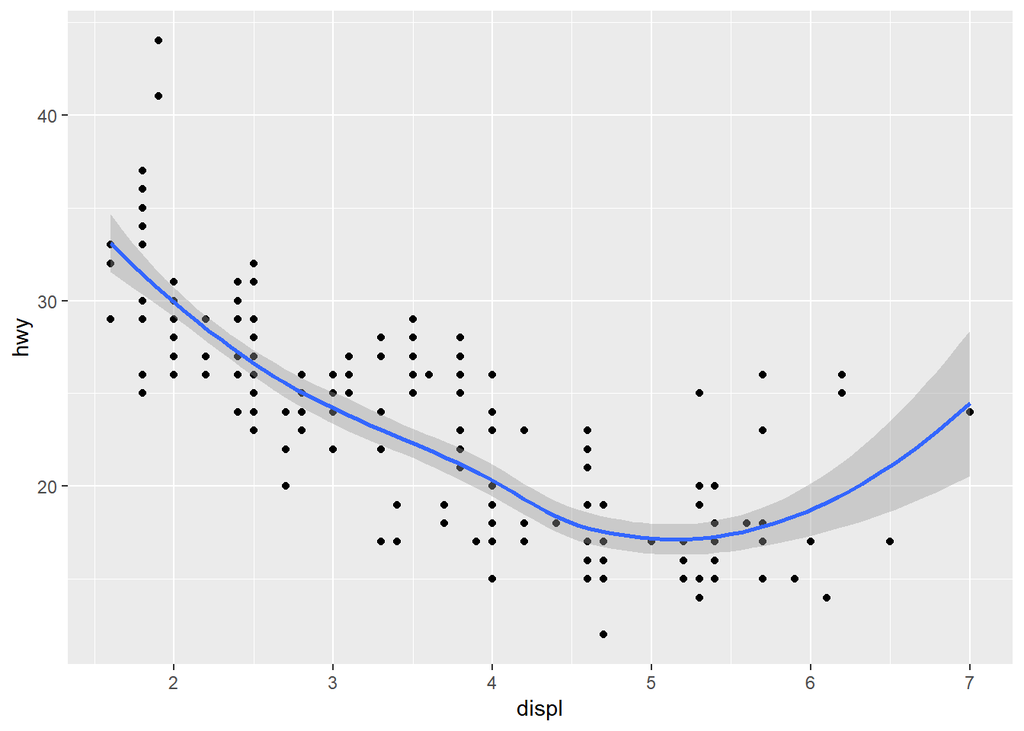

```r
ggplot(data = mpg, mapping = aes(x = displ, y = hwy)) +
  geom_point() +
  geom_smooth()
```

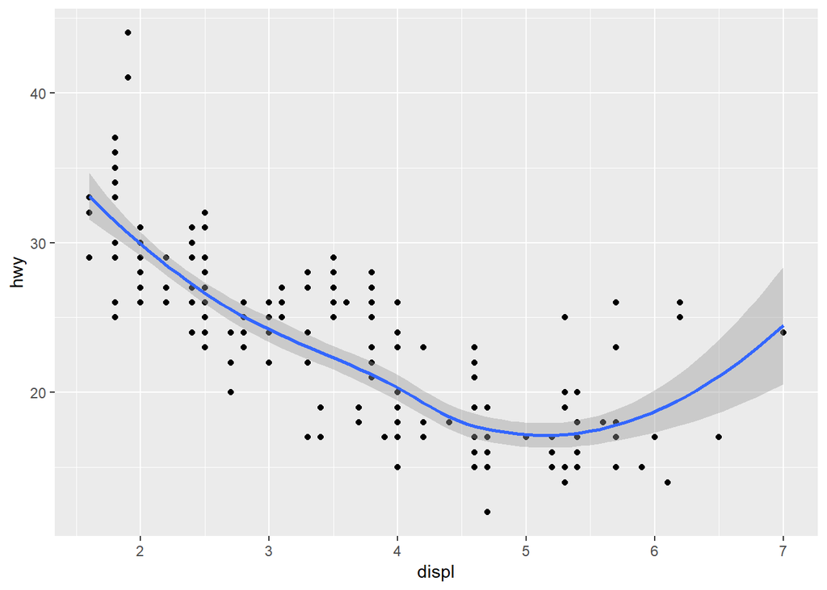

```r
ggplot() +
  geom_point(data = mpg, mapping = aes(x = displ, y = hwy)) +
  geom_smooth(data = mpg, mapping = aes(x = displ, y = hwy))
```

Answer -No because they use the same data and mapping settings. The only difference is that by storing it in the ggplot() function, it is automatically reused for each layer.

## 6 - Recreate the R code necessary to generate the following graphs.

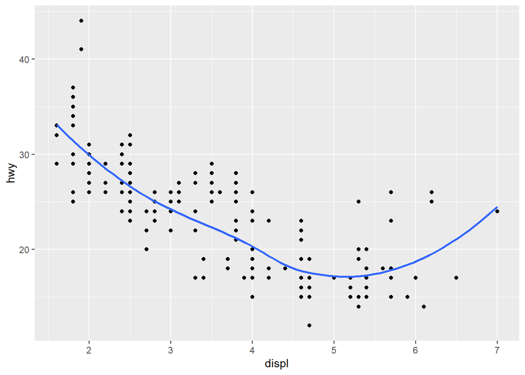

```r
ggplot(data = mpg, mapping = aes(x = displ, y = hwy)) +
  geom_point() +
  geom_smooth(se = FALSE)
```

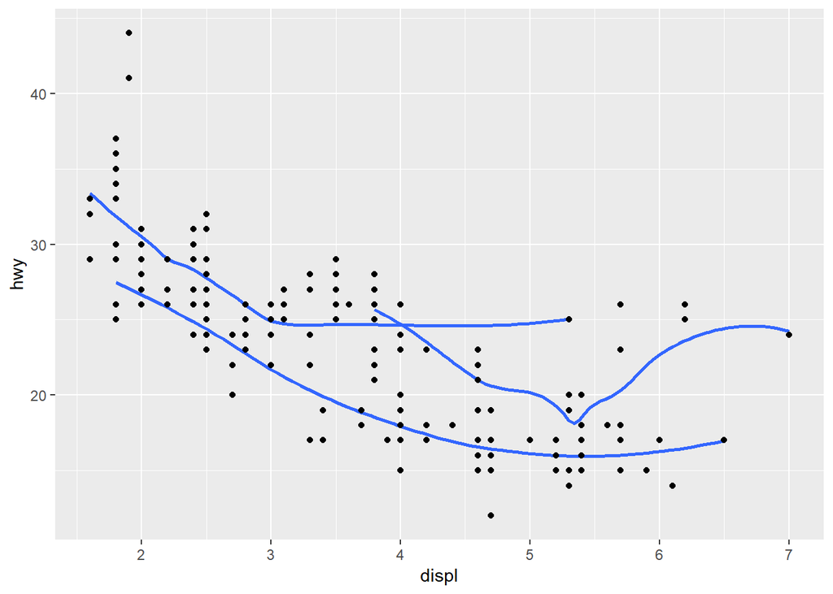

```r
ggplot(data = mpg, mapping = aes(x = displ, y = hwy)) +
  geom_smooth(aes(group = drv), se = FALSE) +
  geom_point()
```

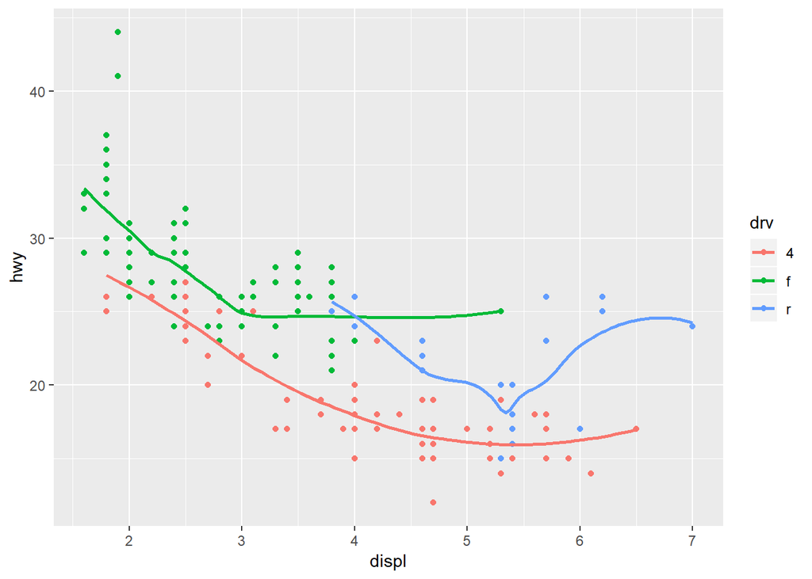

```r
ggplot(data = mpg, mapping = aes(x = displ, y = hwy, color = drv)) +
  geom_point() +
  geom_smooth(se = FALSE)
```

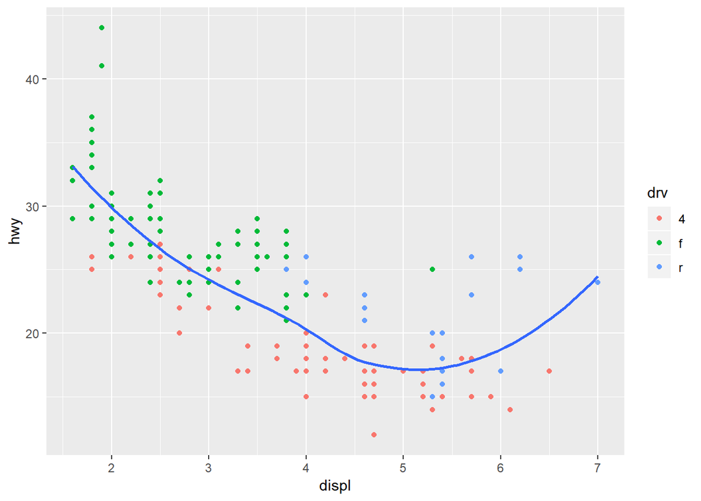

```r
ggplot(data = mpg, mapping = aes(x = displ, y = hwy)) +
  geom_point(aes(color = drv)) +
  geom_smooth(se = FALSE)
```

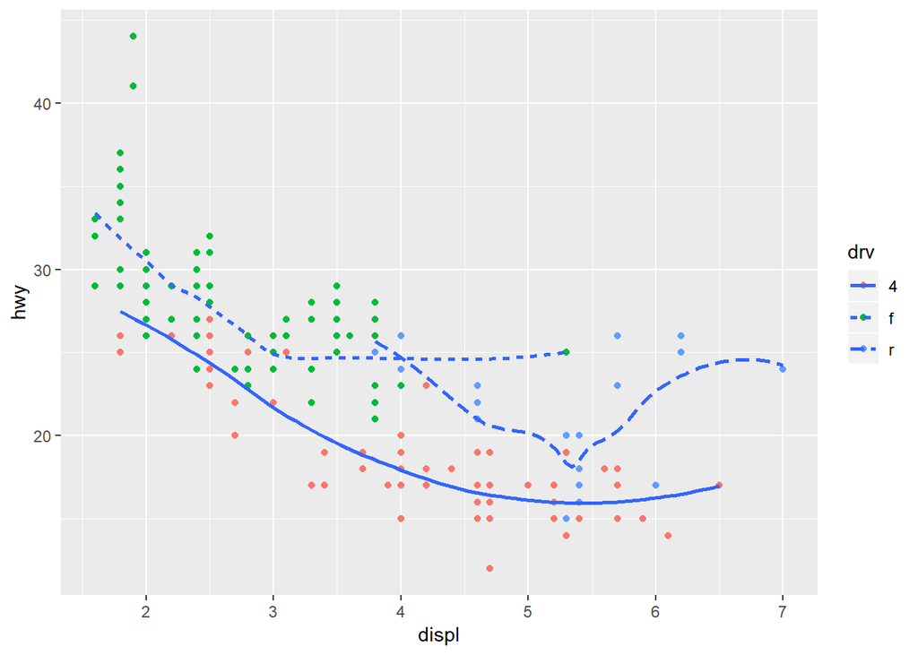

```r
ggplot(data = mpg, mapping = aes(x = displ, y = hwy)) +
  geom_point(aes(color = drv)) +
  geom_smooth(aes(linetype = drv), se = FALSE)
```

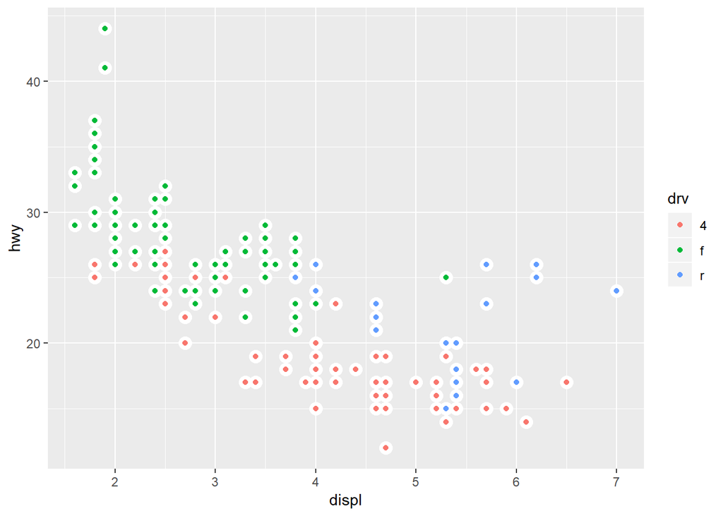

```r
ggplot(data = mpg, mapping = aes(x = displ, y = hwy)) +
  geom_point(size = 4, colour = "white") +
  geom_point(aes(colour = drv))
```

## 3.7.1

## 2 - What does geom_col() do? How is it different to geom_bar()?

`geom_col` leaves the data as it is. `geom_bar()` creates two variables (count and prop) and then graphs the count data on the y axis. With `geom_col` you can plot the values of any x variable against any y variable.